### Assignment 2 Understanding transfer learning and fine tuning

```python
import torch
import torch.nn as nn
import torch.optim as op2tim
from torch.utils.data import DataLoader, Dataset
import torch.nn.functional as F
import matplotlib.pyplot as plt
from PIL import Image
from torchvision import transforms
from torch.utils.data import random_split
from torchvision import datasets
import os
import numpy as np
from typing import Literal
from torchvision.models import resnet18, ResNet18_Weights
from sklearn.metrics import accuracy_score, confusion_matrix, classification_report, ConfusionMatrixDisplay

from pprint import pprint

print(f"[INFO] Torch infos: {torch.__version__}")
```

```
[INFO] Torch infos: 2.6.0+cu124
```

# We need transform from resnet18 and its weights

```python
transform = ResNet18_Weights.DEFAULT.transforms()
print(transform)
```

```
ImageClassification(
    crop_size=[224]
    resize_size=[256]
    mean=[0.485, 0.456, 0.406]
    std=[0.229, 0.224, 0.225]
    interpolation=InterpolationMode.BILINEAR
)
```

# pick a dataset you can import from

```
from torchvision import datasets
```

# Easy picks:

- Food101
- Flowers102
- DTD
- FGVAircraft

# Other picks:

```
full_train = datasets.OxfordIIITPet(root="data", split="trainval", download=True, transform=transform)
test_ds    = datasets.OxfordIIITPet(root="data", split="test", download=True, transform=transform)
```

# Split the data

```python
data = datasets.Food101(root="Dataset",split="train", transform=transform)

test_ds = datasets.Food101(root="Dataset",split="test", transform=transform)
```

# load the train, validation and test split

```python
print(data)
print(test_ds)
images= len(data)
# print(images)
val_ratio = 0.2
train_images = int(images *(1-val_ratio))
val_images = int(images*val_ratio)
class_names = data.classes
print (f'toatl images {images}, val images {val_images}, train images {train_images}')

pprint(len(class_names))
```

```
Dataset Food101
    Number of datapoints: 75750
    Root location: Dataset
    split=train
    StandardTransform
Transform: ImageClassification(
               crop_size=[224]
               resize_size=[256]
               mean=[0.485, 0.456, 0.406]
               std=[0.229, 0.224, 0.225]
               interpolation=InterpolationMode.BILINEAR
           )
Dataset Food101
    Number of datapoints: 25250
    Root location: Dataset
    split=test
    StandardTransform
Transform: ImageClassification(
               crop_size=[224]
               resize_size=[256]
               mean=[0.485, 0.456, 0.406]
               std=[0.229, 0.224, 0.225]
               interpolation=InterpolationMode.BILINEAR
           )
toatl images 75750, val images 15150, train images 60600
101
```

```python
train_split, val_split = random_split(data, [train_images,val_images])
```

# create dataloader handler from the dataset

```python
train_loader = DataLoader(train_split,batch_size=128,shuffle = True, num_workers=4,pin_memory=True)
val_loader = DataLoader(val_split,batch_size=128,shuffle = False, num_workers=4,pin_memory=True)
test_loader =  DataLoader(test_ds,batch_size=128,shuffle = True, num_workers=4,pin_memory=True)
```

# now create the cnn, use the resnet18 as backbone, and ResNet18_Weights as initial weights.

- create the backbone
- create a classifier
- based on your dataset add the correct number of output classes
- the classifier have to be trainable.

# Question 1?

- Why we freeze the backbone? Why not the classifier?

Because I am not training the model. I am using the already trained model so the model already knows how to recognise edges, textures and shapes. If i didnt freeze the backbone, that would trigger back propagation to re adjust the weights. I am freezingthe backbone so the classifier can first learn how to interpret existing features specifically for Food101 labels.

# add the train evaluation, and predict functions here

```python
model = resnet18(weights=ResNet18_Weights.DEFAULT)
print(model.layer4)
print(model.fc)
```

```
Sequential(
  (0): BasicBlock(
    (conv1): Conv2d(256, 512, kernel_size=(3, 3), stride=(2, 2), padding=(1, 1), bias=False)
    (bn1): BatchNorm2d(512, eps=1e-05, momentum=0.1, affine=True, track_running_stats=True)
    (relu): ReLU(inplace=True)
    (conv2): Conv2d(512, 512, kernel_size=(3, 3), stride=(1, 1), padding=(1, 1), bias=False)
    (bn2): BatchNorm2d(512, eps=1e-05, momentum=0.1, affine=True, track_running_stats=True)
    (downsample): Sequential(
      (0): Conv2d(256, 512, kernel_size=(1, 1), stride=(2, 2), bias=False)
      (1): BatchNorm2d(512, eps=1e-05, momentum=0.1, affine=True, track_running_stats=True)
    )
  )
  (1): BasicBlock(
    (conv1): Conv2d(512, 512, kernel_size=(3, 3), stride=(1, 1), padding=(1, 1), bias=False)
    (bn1): BatchNorm2d(512, eps=1e-05, momentum=0.1, affine=True, track_running_stats=True)
    (relu): ReLU(inplace=True)
    (conv2): Conv2d(512, 512, kernel_size=(3, 3), stride=(1, 1), padding=(1, 1), bias=False)
    (bn2): BatchNorm2d(512, eps=1e-05, momentum=0.1, affine=True, track_running_stats=True)
  )
)
Linear(in_features=512, out_features=1000, bias=True)
```

```python
model.fc = nn.Linear(512, 101)
pprint(model.fc)
```

```
Linear(in_features=512, out_features=101, bias=True)
```

I just realized that I dont need to do this manually and follow the function given in the slides. I hope that isnt an issue.

```python
#this was the class and method shown in the lecture.
class ResNet18Transfer(nn.Module):
    def __init__(self,
                 number_of_output_classes: int,
                 freeze_backbone: bool,
                 dense_units: list[int] = [256],
                 dropout_probabilities: float = 0.3,
                 weights=ResNet18_Weights.DEFAULT):

        super().__init__()

        self.weights = weights

        # create a feature extractor
        backbone = resnet18(weights=weights)
        self.features = nn.Sequential(*list(backbone.children())[:-1])
        self.backbone_out = backbone.fc.in_features

        # freeze the layers
        if freeze_backbone:
            for p in self.features.parameters():
                p.requires_grad = False

        # classifier
        mlp = []
        cur = self.backbone_out
        for h in dense_units:
            mlp += [
                nn.Linear(cur, h),
                nn.ReLU(inplace=True),
                nn.Dropout(p=dropout_probabilities),
            ]
            cur = h

        # add final classifier
        self.classifier = nn.Sequential(*mlp)

        # create final layer
        self.final_classifier = nn.Linear(cur, number_of_output_classes)

        # ensure head trainable
        for p in self.classifier.parameters():
            p.requires_grad = True
        for p in self.final_classifier.parameters():
            p.requires_grad = True

    def forward(self, x):
        x = self.features(x)
        x = torch.flatten(x, 1)
        x = self.classifier(x)
        return self.final_classifier(x)

    def get_transform(self):
        # This returns the recommended preprocessing for the pretrained weights
        return self.weights.transforms()

    def fine_tune(self, unfreeze=True):
    # This targets the last block of the feature extractor (layer4)
        for param in self.features[7].parameters():
            param.requires_grad = unfreeze
```

```python
def train_one_epoch(model, train_loader, optimizer, criterion, device="cuda"):
    model.train()
    running_loss = 0.0
    correct = 0
    total = 0
    for images, labels in train_loader:
        images, labels = images.to(device), labels.to(device)
        optimizer.zero_grad()
        logits = model(images)
        loss = criterion(logits, labels)
        loss.backward()
        optimizer.step()
        running_loss += loss.item() * images.size(0)
        preds = logits.argmax(dim=1)
        correct += (preds == labels).sum().item()
        total += labels.size(0)
    return running_loss / len(train_loader.dataset),  correct / total
```

```python
@torch.no_grad()
def evaluate(model, val_loader, criterion, device="cuda"):
    model.eval()
    correct,total = 0, 0
    running_loss = 0.0

    for images, labels in val_loader:
        images, labels = images.to(device), labels.to(device)
        logits = model(images)
        loss = criterion(logits, labels)
        current_image_loss = loss.item()
        running_loss += current_image_loss * images.size(0)

        preds = logits.argmax(dim=1)
        correct += (preds == labels).sum().item()
        total += labels.size(0)
    return running_loss/total, correct / total
```

```python
@torch.no_grad()
def predict(model, images, device, class_names, topk=1):
    model.eval()
    images=images.to(device)
    logits = model(images)
    probs = F.softmax(logits, dim=1)
    topk_probs, topk_indices = probs.topk(topk, dim=1)
    results = []
    for i in range(images.size(0)):
        preds = []
        for j in range(topk):
            idx = int(topk_indices[i, j].item())
            p = topk_probs[i, j].item()
            label = class_names[idx] if class_names else idx
            preds.append({"Label":label, "index":idx, "probability":p})
        results.append({"topk":preds})
    return results
```

### Phase 1: Transfer learning

# freeze all layers except the classifier.

- train and evaluate the model for 50 epochs
- remember to save val loss and train loss

```python
device = "cuda" if torch.cuda.is_available() else "cpu"
print(f"Using device: {device}")
```

```
Using device: cuda
```

```python
epochs = 50
best_val_acc = 0.0

train_loss_history = []
val_loss_history = []
train_acc_history = []
val_acc_history = []

model_params = {
    "number_of_output_classes":101,
    "freeze_backbone": True,
    "dense_units":[256],
    "dropout_probabilities":0.3
    }
model = ResNet18Transfer(**model_params)


trainable_params = []
for p in model.parameters():
    if p.requires_grad:
        trainable_params.append(p)


optimizer = op2tim.Adam(trainable_params, lr=1e-3)

loss_fn = nn.CrossEntropyLoss()

device = "cuda" if torch.cuda.is_available() else "cpu"
model.to(device)
for i in range(epochs):
    train_loss, train_acc = train_one_epoch(model, train_loader, optimizer, loss_fn, device)
    val_loss, val_acc = evaluate(model, val_loader, loss_fn,device=device)
    train_loss_history.append(train_loss)
    val_loss_history.append(val_loss)
    train_acc_history.append(train_acc)
    val_acc_history.append(val_acc)
    print(f"Epoch {i+1}/{epochs} - Train Loss: {train_loss:.4f}, Train Acc: {train_acc:.4f}, Val Loss: {val_loss:.4f}, Val Acc: {val_acc:.4f}")
    if val_acc > best_val_acc:
        best_val_acc = val_acc
        torch.save(model.state_dict(), "best_model.pth")
```

[output not shown]

# Plot accuracy and loss

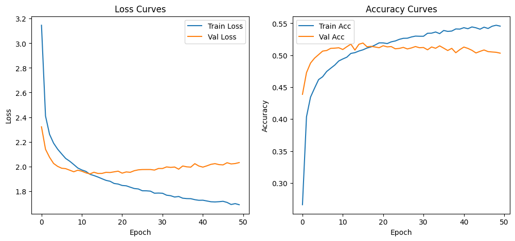

```python
plt.figure(figsize=(12, 5))
plt.subplot(1, 2, 1)
plt.plot(train_loss_history, label="Train Loss")
plt.plot(val_loss_history, label="Val Loss")
plt.title("Loss Curves")
plt.xlabel("Epoch")
plt.ylabel("Loss")
plt.legend()
plt.subplot(1, 2, 2)
plt.plot(train_acc_history, label="Train Acc")
plt.plot(val_acc_history, label="Val Acc")
plt.title("Accuracy Curves")
plt.xlabel("Epoch")
plt.ylabel("Accuracy")
plt.legend()
plt.show()
```

# plot predictions

[figure not shown]

```python
model.load_state_dict(torch.load("best_model.pth"))



images, labels = next(iter(test_loader))
results = predict(model, images, device, class_names=class_names)


plt.figure(figsize=(15,12))
rows,cols = 3,3
# i had to get the transforms to reverse them to print the pictures
IMAGE_MEAN = np.array([0.485, 0.456, 0.406])
IMAGE_STD = np.array([0.229, 0.224, 0.225])


for i in range(rows*cols):
    plt.subplot(rows, cols, i + 1)

    img = images[i].cpu().numpy().transpose((1, 2, 0))
    img = img * IMAGE_STD + IMAGE_MEAN
    img = np.clip(img, 0, 1)

    plt.imshow(img)

    predicted_data = results[i]['topk'][0]
    pred_label = predicted_data['Label']
    p_val = predicted_data['probability']

    gt = class_names[labels[i]]

    color = "green" if pred_label == gt else "red"
    plt.title(f"P: {pred_label} ({p_val:.2%})\nT: {gt}", color=color)
    plt.axis('off')

plt.tight_layout()
plt.show()
```

# calculate TEST accuracy score

```python
test_loss, test_acc = evaluate(model, test_loader, loss_fn, device=device)
print(f"Test Loss: {test_loss:.4f} | Test Accuracy: {test_acc:.4f}")
```

```
Test Loss: 1.7088 | Test Accuracy: 0.5553
```

# Calculate confusion matrices precision and recall

```
Number of Predictions 25250 and, LAbels 25250
                         precision    recall  f1-score   support

              apple_pie       0.28      0.24      0.26       250
         baby_back_ribs       0.43      0.50      0.46       250
                baklava       0.48      0.61      0.54       250
         beef_carpaccio       0.48      0.59      0.53       250
           beef_tartare       0.41      0.42      0.42       250
             beet_salad       0.47      0.44      0.46       250
               beignets       0.63      0.75      0.68       250
               bibimbap       0.77      0.70      0.74       250
          bread_pudding       0.37      0.29      0.33       250
      breakfast_burrito       0.44      0.46      0.45       250
             bruschetta       0.51      0.35      0.41       250
           caesar_salad       0.47      0.65      0.54       250
                cannoli       0.61      0.59      0.60       250
          caprese_salad       0.56      0.50      0.53       250
            carrot_cake       0.60      0.42      0.49       250
                ceviche       0.38      0.22      0.28       250
           cheese_plate       0.60      0.49      0.54       250
             cheesecake       0.43      0.37      0.40       250
          chicken_curry       0.42      0.41      0.41       250
     chicken_quesadilla       0.42      0.60      0.49       250
          chicken_wings       0.59      0.68      0.64       250
         chocolate_cake       0.54      0.42      0.47       250
       chocolate_mousse       0.50      0.31      0.39       250
                churros       0.65      0.70      0.68       250
           clam_chowder       0.63      0.77      0.69       250
          club_sandwich       0.58      0.55      0.56       250
             crab_cakes       0.38      0.32      0.35       250
           creme_brulee       0.63      0.69      0.66       250
          croque_madame       0.57      0.60      0.58       250
              cup_cakes       0.70      0.77      0.73       250
           deviled_eggs       0.63      0.68      0.66       250
                 donuts       0.69      0.69      0.69       250
              dumplings       0.85      0.85      0.85       250
                edamame       0.90      0.97      0.93       250
          eggs_benedict       0.69      0.66      0.67       250
              escargots       0.64      0.76      0.69       250
                falafel       0.60      0.52      0.56       250
```

[output cut: 53 more lines]

```
    spaghetti_bolognese       0.62      0.74      0.68       250
    spaghetti_carbonara       0.89      0.71      0.79       250
           spring_rolls       0.64      0.58      0.61       250
                  steak       0.32      0.22      0.26       250
   strawberry_shortcake       0.55      0.51      0.53       250
                  sushi       0.45      0.62      0.52       250
                  tacos       0.32      0.32      0.32       250
               takoyaki       0.53      0.65      0.59       250
               tiramisu       0.38      0.52      0.44       250
           tuna_tartare       0.42      0.23      0.30       250
                waffles       0.62      0.64      0.63       250

               accuracy                           0.56     25250
              macro avg       0.56      0.56      0.55     25250
           weighted avg       0.56      0.56      0.55     25250
```

```
<sklearn.metrics._plot.confusion_matrix.ConfusionMatrixDisplay at 0x7fae68cce660>
```

[figure not shown]

```python
with torch.no_grad():
    model.eval()
    all_preds = []
    all_labels =[]
    correct, total = 0,0
    for images, labels in test_loader:
        images, labels = images.to(device), labels.to(device)
        logits = model(images)

        preds = logits.argmax(dim=1)
        all_preds.extend(preds.cpu().tolist())
        all_labels.extend(labels.cpu().tolist())

        correct += (preds == labels).sum().item()
        total += labels.size(0)

# print(correct / total)

print(f'Number of Predictions {len(all_preds)} and, LAbels {len(all_labels)}')


print(classification_report(all_labels,all_preds, target_names=class_names))

cm = confusion_matrix(all_labels,all_preds)
disp = ConfusionMatrixDisplay(confusion_matrix=cm,display_labels = class_names)

disp.plot(cmap="Blues")
```

I cant make sense out of this confusion matrix. should I only focuse on the errors? or just plot the top errors? 101 classes make no sense. or I can plot with 20 classes?

```python
# Zeroing out the correct guesses to see only the errors
np.fill_diagonal(cm, 0)
top_errors = np.unravel_index(np.argsort(cm, axis=None)[-5:], cm.shape)

print("\nTop 5 Most Frequent Confusions:")
for i in range(4, -1, -1): # Printing the highest errors first
    true_idx, pred_idx = top_errors[0][i], top_errors[1][i]
    count = cm[true_idx, pred_idx]
    print(f"True: {class_names[true_idx]} mistook for {class_names[pred_idx]} ({count} times)")
```

```
Top 5 Most Frequent Confusions:
True: pulled_pork_sandwich mistook for hamburger (51 times)
True: steak mistook for filet_mignon (33 times)
True: pork_chop mistook for filet_mignon (33 times)
True: chocolate_cake mistook for tiramisu (31 times)
True: ceviche mistook for greek_salad (30 times)
```

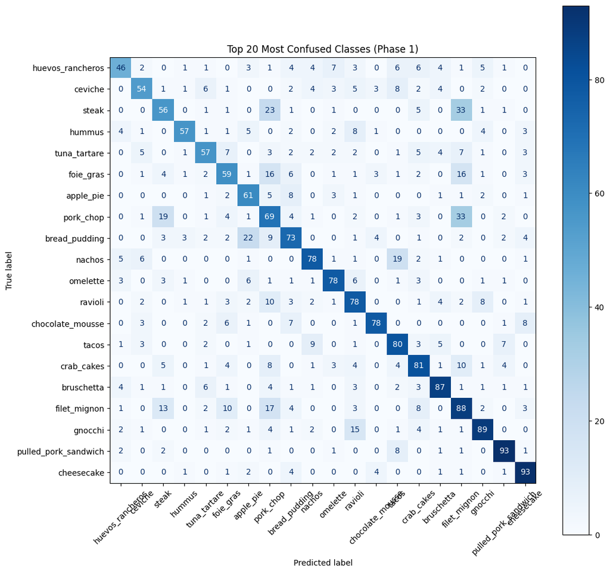

```python
cm = confusion_matrix(all_labels, all_preds)

troublesome_indices = np.argsort(cm.diagonal())[:20]
cm_small = cm[troublesome_indices][:, troublesome_indices]
subset_names = [class_names[i] for i in troublesome_indices]

fig, ax = plt.subplots(figsize=(12, 12))
disp = ConfusionMatrixDisplay(confusion_matrix=cm_small, display_labels=subset_names)
disp.plot(cmap="Blues", ax=ax, xticks_rotation=45, values_format='d')

plt.title("Top 20 Most Confused Classes (Phase 1)")
plt.show()
```

# from the freezed cnn unfreeze the `layer4`.

# Train for 50 epochs

```python
model_params = {
    "number_of_output_classes":101,
    "freeze_backbone": True,
    "dense_units":[256],
    "dropout_probabilities":0.3
    }
model = ResNet18Transfer(**model_params)

model.load_state_dict(torch.load("best_model.pth"))

device = "cuda" if torch.cuda.is_available() else "cpu"
model.to(device)
model.fine_tune(unfreeze=True)

trainable_params = [p for p in model.parameters() if p.requires_grad]
print(f"Number of trainable parameters groups: {len(trainable_params)}")

optimizer_ft = op2tim.Adam([p for p in model.parameters() if p.requires_grad], lr=1e-4, weight_decay=1e-4)
loss_fn = nn.CrossEntropyLoss()

epochs_ft = 50
best_val_acc_ft = 0.0
ft_train_loss_hist, ft_val_loss_hist = [], []
ft_train_acc_hist, ft_val_acc_hist = [], []

for epoch in range(epochs_ft):
    train_loss, train_acc = train_one_epoch(model, train_loader, optimizer_ft, loss_fn, device)
    val_loss, val_acc = evaluate(model, val_loader, loss_fn, device=device)

    ft_train_loss_hist.append(train_loss)
    ft_val_loss_hist.append(val_loss)
    ft_train_acc_hist.append(train_acc)
    ft_val_acc_hist.append(val_acc)

    print(f"FT Epoch {epoch+1}/{epochs_ft} | Train Acc: {train_acc:.4f} | Val Acc: {val_acc:.4f}")

    if val_acc > best_val_acc_ft:
        best_val_acc_ft = val_acc
        torch.save(model.state_dict(), "best_model_finetuned.pth")
```

```
Number of trainable parameters groups: 19
FT Epoch 1/50 | Train Acc: 0.5588 | Val Acc: 0.5991
FT Epoch 2/50 | Train Acc: 0.6795 | Val Acc: 0.6211
FT Epoch 3/50 | Train Acc: 0.7614 | Val Acc: 0.6242
FT Epoch 4/50 | Train Acc: 0.8284 | Val Acc: 0.6233
FT Epoch 5/50 | Train Acc: 0.8824 | Val Acc: 0.6262
FT Epoch 6/50 | Train Acc: 0.9182 | Val Acc: 0.6205
FT Epoch 7/50 | Train Acc: 0.9399 | Val Acc: 0.6249
FT Epoch 8/50 | Train Acc: 0.9550 | Val Acc: 0.6208
FT Epoch 9/50 | Train Acc: 0.9635 | Val Acc: 0.6225
FT Epoch 10/50 | Train Acc: 0.9699 | Val Acc: 0.6177
FT Epoch 11/50 | Train Acc: 0.9706 | Val Acc: 0.6156
FT Epoch 12/50 | Train Acc: 0.9745 | Val Acc: 0.6148
FT Epoch 13/50 | Train Acc: 0.9753 | Val Acc: 0.6209
FT Epoch 14/50 | Train Acc: 0.9797 | Val Acc: 0.6180
FT Epoch 15/50 | Train Acc: 0.9807 | Val Acc: 0.6190
FT Epoch 16/50 | Train Acc: 0.9807 | Val Acc: 0.6145
FT Epoch 17/50 | Train Acc: 0.9818 | Val Acc: 0.6178
FT Epoch 18/50 | Train Acc: 0.9826 | Val Acc: 0.6191
FT Epoch 19/50 | Train Acc: 0.9829 | Val Acc: 0.6189
FT Epoch 20/50 | Train Acc: 0.9856 | Val Acc: 0.6217
FT Epoch 21/50 | Train Acc: 0.9870 | Val Acc: 0.6174
FT Epoch 22/50 | Train Acc: 0.9869 | Val Acc: 0.6123
FT Epoch 23/50 | Train Acc: 0.9859 | Val Acc: 0.6113
FT Epoch 24/50 | Train Acc: 0.9860 | Val Acc: 0.6189
FT Epoch 25/50 | Train Acc: 0.9872 | Val Acc: 0.6157
FT Epoch 26/50 | Train Acc: 0.9890 | Val Acc: 0.6084
FT Epoch 27/50 | Train Acc: 0.9878 | Val Acc: 0.6168
FT Epoch 28/50 | Train Acc: 0.9895 | Val Acc: 0.6192
FT Epoch 29/50 | Train Acc: 0.9887 | Val Acc: 0.6143
FT Epoch 30/50 | Train Acc: 0.9902 | Val Acc: 0.6121
FT Epoch 31/50 | Train Acc: 0.9897 | Val Acc: 0.6110
FT Epoch 32/50 | Train Acc: 0.9897 | Val Acc: 0.6135
FT Epoch 33/50 | Train Acc: 0.9890 | Val Acc: 0.6096
FT Epoch 34/50 | Train Acc: 0.9911 | Val Acc: 0.6208
FT Epoch 35/50 | Train Acc: 0.9914 | Val Acc: 0.6201
FT Epoch 36/50 | Train Acc: 0.9913 | Val Acc: 0.6168
FT Epoch 37/50 | Train Acc: 0.9911 | Val Acc: 0.6178
FT Epoch 38/50 | Train Acc: 0.9914 | Val Acc: 0.6153
FT Epoch 39/50 | Train Acc: 0.9914 | Val Acc: 0.6144
FT Epoch 40/50 | Train Acc: 0.9924 | Val Acc: 0.6176
FT Epoch 41/50 | Train Acc: 0.9911 | Val Acc: 0.6141
FT Epoch 42/50 | Train Acc: 0.9907 | Val Acc: 0.6155
FT Epoch 43/50 | Train Acc: 0.9933 | Val Acc: 0.6134
FT Epoch 44/50 | Train Acc: 0.9921 | Val Acc: 0.6164
FT Epoch 45/50 | Train Acc: 0.9928 | Val Acc: 0.6197
FT Epoch 46/50 | Train Acc: 0.9925 | Val Acc: 0.6134
FT Epoch 47/50 | Train Acc: 0.9931 | Val Acc: 0.6154
FT Epoch 48/50 | Train Acc: 0.9934 | Val Acc: 0.6213
FT Epoch 49/50 | Train Acc: 0.9946 | Val Acc: 0.6206
FT Epoch 50/50 | Train Acc: 0.9938 | Val Acc: 0.6208
```

# Plot curves

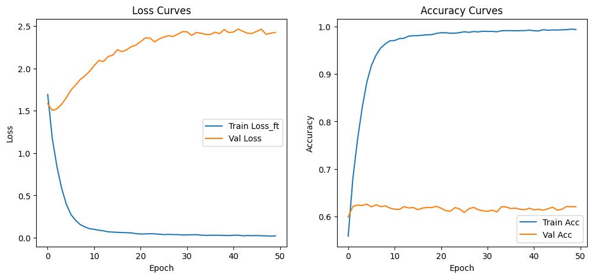

```python
plt.figure(figsize=(12, 5))
plt.subplot(1, 2, 1)
plt.plot(ft_train_loss_hist, label="Train Loss_ft")
plt.plot(ft_val_loss_hist, label="Val Loss")
plt.title("Loss Curves")
plt.xlabel("Epoch")
plt.ylabel("Loss")
plt.legend()
plt.subplot(1, 2, 2)
plt.plot(ft_train_acc_hist, label="Train Acc")
plt.plot(ft_val_acc_hist, label="Val Acc")
plt.title("Accuracy Curves")
plt.xlabel("Epoch")
plt.ylabel("Accuracy")
plt.legend()
plt.show()
```

# visualize prediction

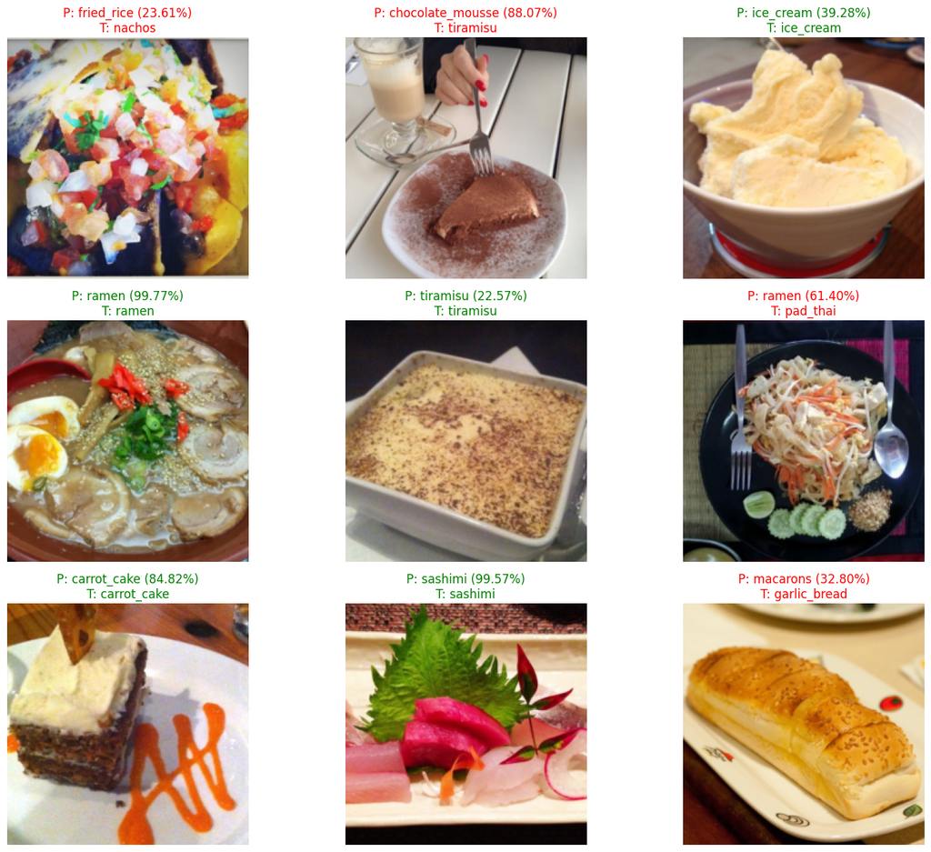

```python
model.load_state_dict(torch.load("best_model_finetuned.pth"))


images, labels = next(iter(test_loader))
results = predict(model, images, device, class_names=class_names)


plt.figure(figsize=(15,12))
rows,cols = 3,3
# i had to get the transforms to reverse them to print the pictures
IMAGE_MEAN = np.array([0.485, 0.456, 0.406])
IMAGE_STD = np.array([0.229, 0.224, 0.225])


for i in range(rows*cols):
    plt.subplot(rows, cols, i + 1)

    img = images[i].cpu().numpy().transpose((1, 2, 0))
    img = img * IMAGE_STD + IMAGE_MEAN
    img = np.clip(img, 0, 1)

    plt.imshow(img)

    predicted_data = results[i]['topk'][0]
    pred_label = predicted_data['Label']
    p_val = predicted_data['probability']

    gt = class_names[labels[i]]

    color = "green" if pred_label == gt else "red"
    plt.title(f"P: {pred_label} ({p_val:.2%})\nT: {gt}", color=color)
    plt.axis('off')

plt.tight_layout()
plt.show()
```

# Calculate test accuracy score

```python
test_loss, test_acc = evaluate(model, test_loader, loss_fn, device=device)
print(f"Test Loss: {test_loss:.4f} | Test Accuracy: {test_acc:.4f}")
```

```
Test Loss: 1.3132 | Test Accuracy: 0.6768
```

# calculate confusion matrix precision and recall

```
Number of Predictions 25250 and, Labels 25250
                         precision    recall  f1-score   support

              apple_pie       0.42      0.36      0.39       250
         baby_back_ribs       0.71      0.65      0.68       250
                baklava       0.67      0.77      0.72       250
         beef_carpaccio       0.69      0.72      0.70       250
           beef_tartare       0.61      0.62      0.62       250
             beet_salad       0.52      0.63      0.57       250
               beignets       0.79      0.78      0.79       250
               bibimbap       0.82      0.82      0.82       250
          bread_pudding       0.45      0.45      0.45       250
      breakfast_burrito       0.62      0.53      0.57       250
             bruschetta       0.47      0.62      0.53       250
           caesar_salad       0.76      0.72      0.74       250
                cannoli       0.74      0.72      0.73       250
          caprese_salad       0.60      0.73      0.66       250
            carrot_cake       0.64      0.66      0.65       250
                ceviche       0.50      0.46      0.48       250
           cheese_plate       0.71      0.68      0.70       250
             cheesecake       0.55      0.60      0.57       250
          chicken_curry       0.64      0.43      0.52       250
     chicken_quesadilla       0.77      0.67      0.71       250
          chicken_wings       0.68      0.79      0.73       250
         chocolate_cake       0.64      0.64      0.64       250
       chocolate_mousse       0.49      0.55      0.52       250
                churros       0.85      0.79      0.82       250
           clam_chowder       0.81      0.79      0.80       250
          club_sandwich       0.79      0.69      0.74       250
             crab_cakes       0.46      0.53      0.49       250
           creme_brulee       0.82      0.79      0.81       250
          croque_madame       0.75      0.75      0.75       250
              cup_cakes       0.77      0.84      0.80       250
           deviled_eggs       0.77      0.82      0.79       250
                 donuts       0.73      0.69      0.71       250
              dumplings       0.88      0.87      0.87       250
                edamame       0.97      0.98      0.97       250
          eggs_benedict       0.84      0.71      0.77       250
              escargots       0.76      0.82      0.79       250
                falafel       0.67      0.58      0.62       250
```

[output cut: 53 more lines]

```
    spaghetti_bolognese       0.78      0.87      0.82       250
    spaghetti_carbonara       0.84      0.88      0.86       250
           spring_rolls       0.78      0.70      0.74       250
                  steak       0.41      0.38      0.39       250
   strawberry_shortcake       0.70      0.68      0.69       250
                  sushi       0.71      0.71      0.71       250
                  tacos       0.49      0.48      0.49       250
               takoyaki       0.87      0.72      0.79       250
               tiramisu       0.65      0.61      0.63       250
           tuna_tartare       0.43      0.52      0.47       250
                waffles       0.74      0.78      0.76       250

               accuracy                           0.68     25250
              macro avg       0.69      0.68      0.68     25250
           weighted avg       0.69      0.68      0.68     25250
```

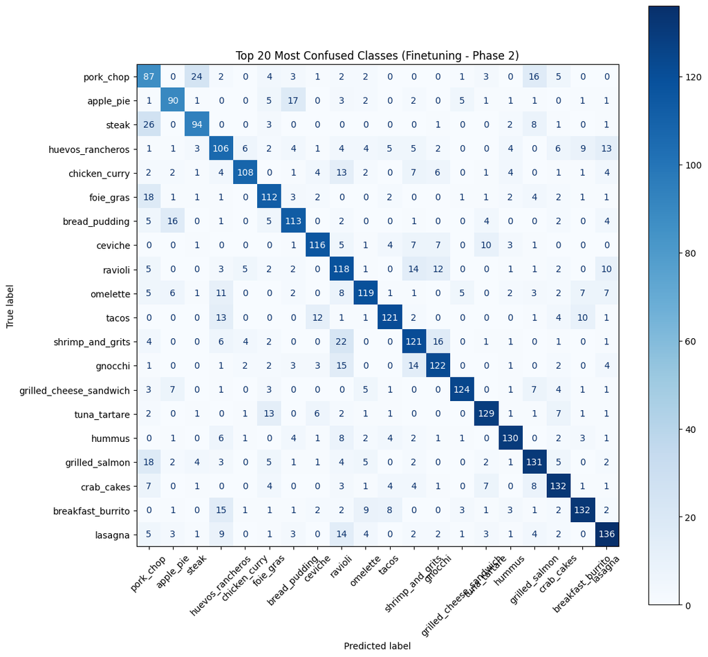

```python
with torch.no_grad():
    model.eval()
    all_preds = []
    all_labels =[]
    correct, total = 0,0
    for images, labels in test_loader:
        images, labels = images.to(device), labels.to(device)
        logits = model(images)

        preds = logits.argmax(dim=1)
        all_preds.extend(preds.cpu().tolist())
        all_labels.extend(labels.cpu().tolist())

        correct += (preds == labels).sum().item()
        total += labels.size(0)

# print(correct / total)

print(f'Number of Predictions {len(all_preds)} and, Labels {len(all_labels)}')


print(classification_report(all_labels,all_preds, target_names=class_names))

cm = confusion_matrix(all_labels,all_preds)

troublesome_indices = np.argsort(cm.diagonal())[:20]
cm_small = cm[troublesome_indices][:, troublesome_indices]
subset_names = [class_names[i] for i in troublesome_indices]

fig, ax = plt.subplots(figsize=(12, 12))
disp = ConfusionMatrixDisplay(confusion_matrix=cm_small, display_labels=subset_names)
disp.plot(cmap="Blues", ax=ax, xticks_rotation=45, values_format='d')

plt.title("Top 20 Most Confused Classes (Finetuning - Phase 2)")
plt.show()
```

# Question 2 What did you learn? What is the difference between transfer learning and fine tuning?

So in transfer learning, I am taking an already trained model and only training a new classifier to classify foods from my food 101 dataset. Here the transfer learning had an accuracy of 55% on the test set. But in the case of fine-tuning, I had to unfreeze the layer 4. to make sure that I do not run into overfitting on the train-set beacuse of the layer 4, I had to set a weight decay rate of 1e-4. Even after that, the train accuracy was very high and validation accuranty stayed around 62%. But good news is the model performed with a 67.68% accuracy on the test set.

Overall I think the previous weight from transfer learning were pretty good to be able to get an accuracy of 55%. On the other hand, fine tuning is hard because it is very easy to overfit the model on the train set. But finetunning improved the model performance as it could train a bit more and specialize on the food classification task.